# Gene Expression Analysis Using R

# 48 Heatmap 6/6

```r
library(gplots) # Load the gplots library
heatmap(filtered, Rowv=row_dendrogram, Colv=col_dendrogram, col = rev(redgreen(1024)))
```

[output not shown]

# 49 Annnotation 1/3

To obtain the functional annotation of the differentially expressed genes, we are going first to extract their probe ids:

```r
filterd_ids = row.names(filtered) # ids of the filtered DE genes
length(filterd_ids)
head(filterd_ids)
```

# 50 Annnotation 2/3

Then we will generate a comprehensive functional annotation via `BioConductor` packages `annaffy` and `mouse4302.db`.

To install `BioConductor` packages (if they are not already installed):

```r
source("http://bioconductor.org/biocLite.R")
biocLite(c("annaffy", "mouse4302.db"))
```

Load the packages and extract annotation of the filtered ids:

```r
library(annaffy)
annotation_table = aafTableAnn(filterd_ids, "mouse4302.db")
saveHTML(annotation_table, file="filtered.html")
browseURL("filtered.html")
```

# 51 Annnotation 3/3

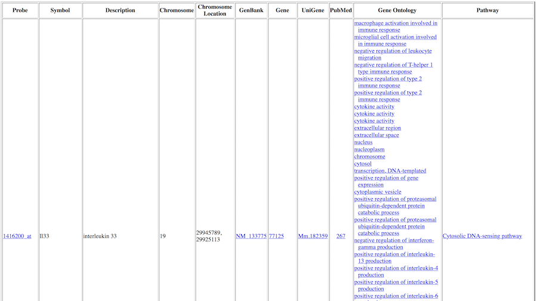

Annotation

# 52 Exercise

Generate separate annotations for the up-regulated and down-regulated differentially expressed genes between `WT` and `KO`. Discuss each set in a molecular context as detailed as possible.

# 53 Solution 1/2

Generating two lists of IDs for the up- and down- regulated genes

```r
up_ids = ids[filter_up] # IDs of up-regulated genes
length(up_ids)
head(up_ids)

down_ids = ids[filter_down] # IDs of down-regulared genes
length(down_ids)
head(down_ids)
```

# 54 Solution 2/2

Obtaining the annotation of the up- and down- regulated genes into tables

```r
up_table = aafTableAnn(up_ids, "mouse4302.db")
head(up_table)
saveHTML(up_table, file="up_table.html")
browseURL("up_table.html")

down_table = aafTableAnn(down_ids, "mouse4302.db")
head(down_table)
saveHTML(down_table, file="down_table.html")
browseURL("down_table.html")
```

# 55 Sanity Check (Irf6)

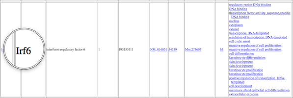

Down Regulation of Irf6

# 56 Thank you!

[figure not shown]